# Penguins Lab

Jaleigh Pier

2/10/2022

## Data

`penguins` and `penguins_raw` datasets contain data for 344 penguins. There are 3 different species of penguins in this dataset, collected from 3 islands in the Palmer Archipelago, Antarctica.

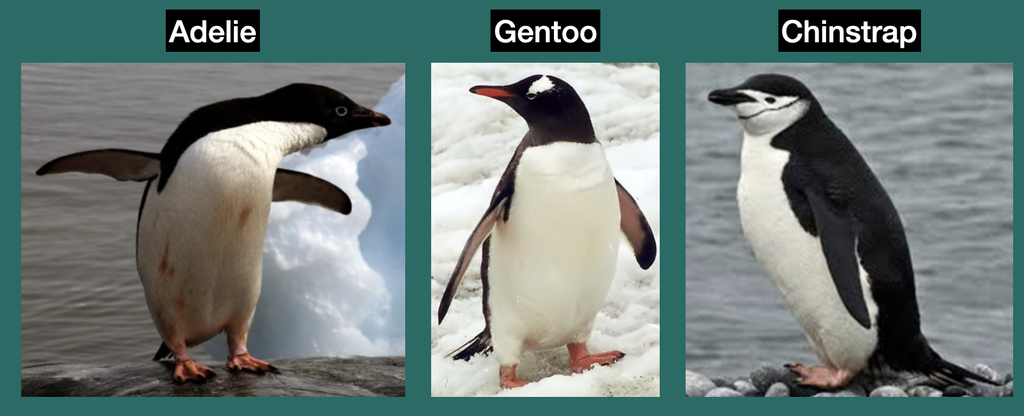

Penguins in this dataset.

```r
#install.packages("palmerpenguins")
library(palmerpenguins)
library(tidyverse)
dim(penguins)
```

```
## [1] 344   8
```

```r
View(penguins)
```

```r
colnames(penguins)
```

```
## [1] "species"           "island"            "bill_length_mm"
## [4] "bill_depth_mm"     "flipper_length_mm" "body_mass_g"
## [7] "sex"               "year"
```

```r
head(penguins)
```

```
## # A tibble: 6 x 8
##   species island bill_length_mm bill_depth_mm flipper_length_~ body_mass_g sex
##   <fct>   <fct>           <dbl>         <dbl>            <int>       <int> <fct>
## 1 Adelie  Torge~           39.1          18.7              181        3750 male
## 2 Adelie  Torge~           39.5          17.4              186        3800 fema~
## 3 Adelie  Torge~           40.3          18                195        3250 fema~
## 4 Adelie  Torge~           NA            NA                 NA          NA <NA>
## 5 Adelie  Torge~           36.7          19.3              193        3450 fema~
## 6 Adelie  Torge~           39.3          20.6              190        3650 male
## # ... with 1 more variable: year <int>
```

```r
str(penguins)
```

```
## tibble [344 x 8] (S3: tbl_df/tbl/data.frame)
##  $ species          : Factor w/ 3 levels "Adelie","Chinstrap",..: 1 1 1 1 1 1 1 1 1 1 ...
##  $ island           : Factor w/ 3 levels "Biscoe","Dream",..: 3 3 3 3 3 3 3 3 3 3 ...
##  $ bill_length_mm   : num [1:344] 39.1 39.5 40.3 NA 36.7 39.3 38.9 39.2 34.1 42 ...
##  $ bill_depth_mm    : num [1:344] 18.7 17.4 18 NA 19.3 20.6 17.8 19.6 18.1 20.2 ...
##  $ flipper_length_mm: int [1:344] 181 186 195 NA 193 190 181 195 193 190 ...
##  $ body_mass_g      : int [1:344] 3750 3800 3250 NA 3450 3650 3625 4675 3475 4250 ...
##  $ sex              : Factor w/ 2 levels "female","male": 2 1 1 NA 1 2 1 2 NA NA ...
##  $ year             : int [1:344] 2007 2007 2007 2007 2007 2007 2007 2007 2007 2007 ...
```

## Single trait

Explore the distribution in any one of the morphological traits in the `penguin` dataset.

For example, what is the lowest and highest bill lengths do penguins in this dataset have? Do different species have different bill lengths? How much do they overlap?

Flipper length

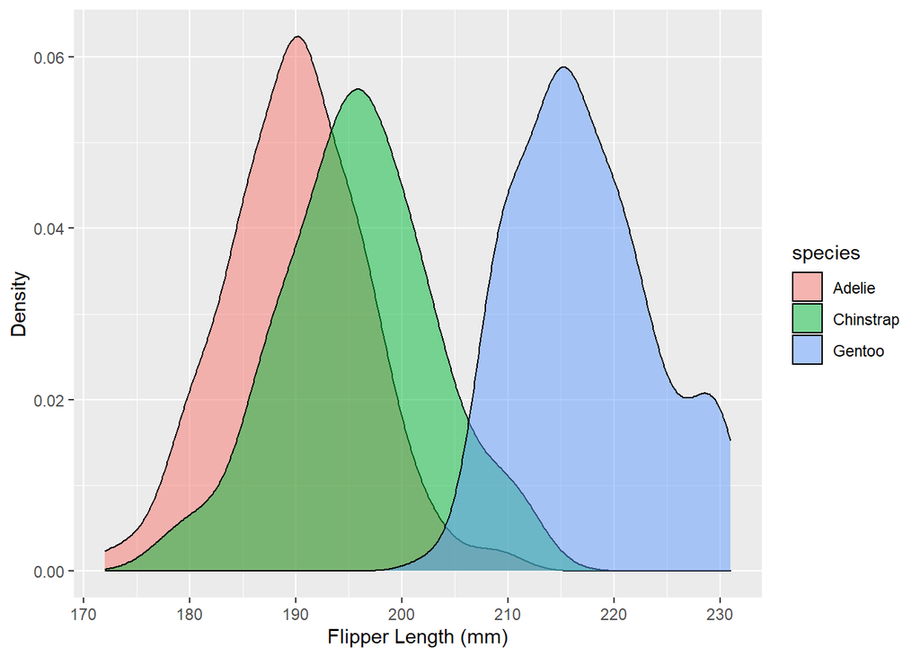

```r
penguins %>%
  ggplot() + geom_density(aes(x=flipper_length_mm, fill=species), alpha = 0.5) +
  xlab("Flipper Length (mm)") + ylab("Density")
```

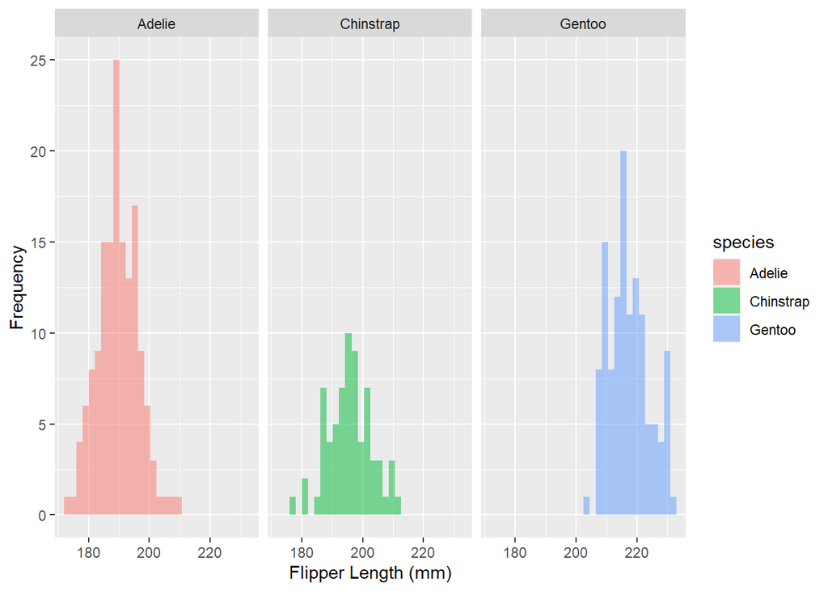

```r
penguins %>%
  ggplot() + geom_histogram(aes(x=flipper_length_mm, fill=species), alpha = 0.5) + facet_wrap(~ species, ncol = 3) + xlab("Flipper Length (mm)") + ylab("Frequency")
```

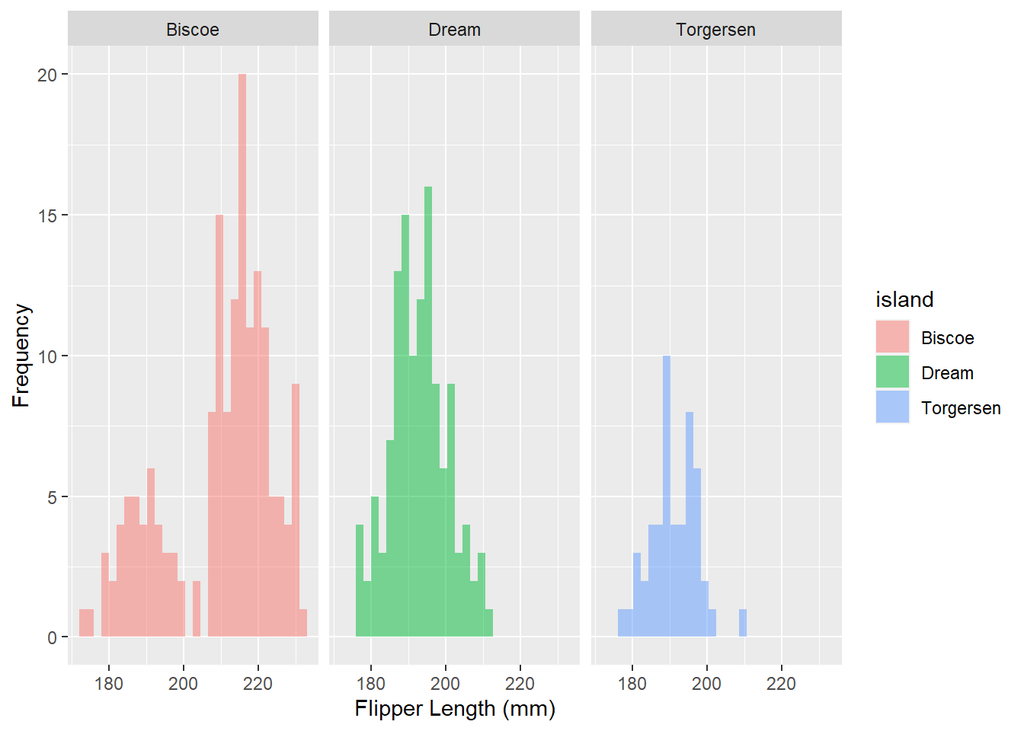

```r
penguins %>%
  ggplot() + geom_histogram(aes(x=flipper_length_mm, fill=island), alpha = 0.5) + facet_wrap(~ island, ncol = 3) + xlab("Flipper Length (mm)") + ylab("Frequency")
```

## Relationship between multiple traits

Explore the relationship between different morphological traits in the `penguins` dataset.

For example, what is the relationship between body mass and flipper length in penguins in this dataset? Does this relationship differ between species? Given the same body mass, which species of penguins tend to have the longest flippers?

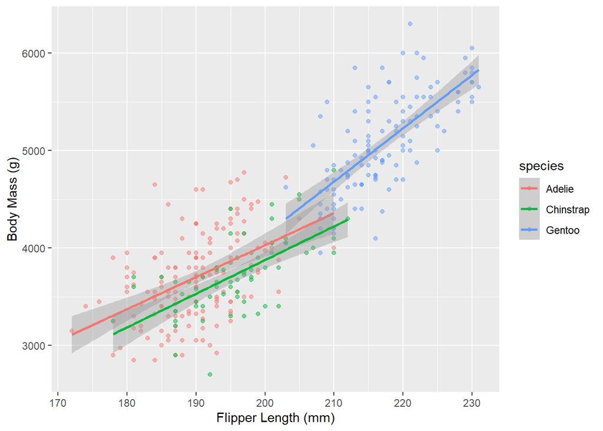

```r
penguins %>%
  ggplot() + geom_point(aes(x=flipper_length_mm, y=body_mass_g, color=species), alpha = 0.5) + xlab("Flipper Length (mm)") + ylab("Body Mass (g)") + geom_smooth(aes(x=flipper_length_mm, y=body_mass_g, color=species), method = "lm")
```

##Sexual dimorphism

Explore the level of sexual dimorphism in different morphological traits in the `penguins` dataset.

For example, what traits are sexually dimorphic in the penguins dataset? Is the level of sexual dimorphism the same in all three penguin species?

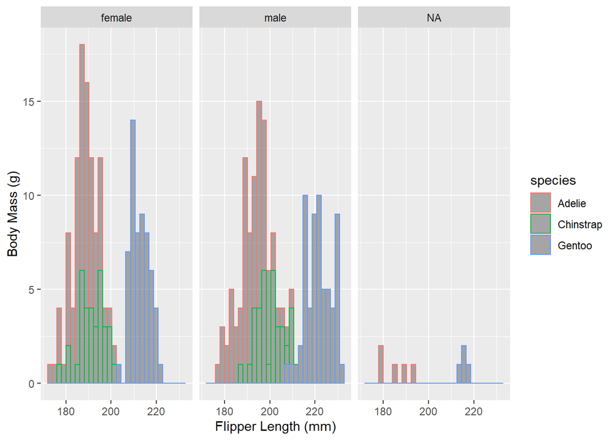

```r
penguins %>%
  ggplot() + geom_histogram(aes(x=flipper_length_mm, color=species), alpha = 0.5) + xlab("Flipper Length (mm)") + ylab("Body Mass (g)") + facet_wrap(~sex, ncol=3)
```

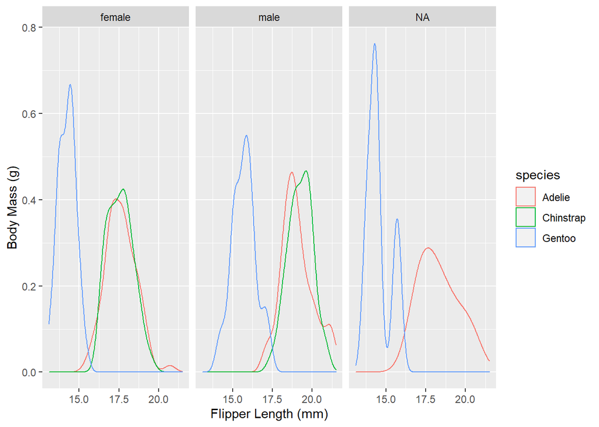

```r
penguins %>%
  ggplot() + geom_density(aes(x=bill_depth_mm, color=species), alpha = 0.5) + xlab("Flipper Length (mm)") + ylab("Body Mass (g)") + facet_wrap(~sex, ncol=3)
```

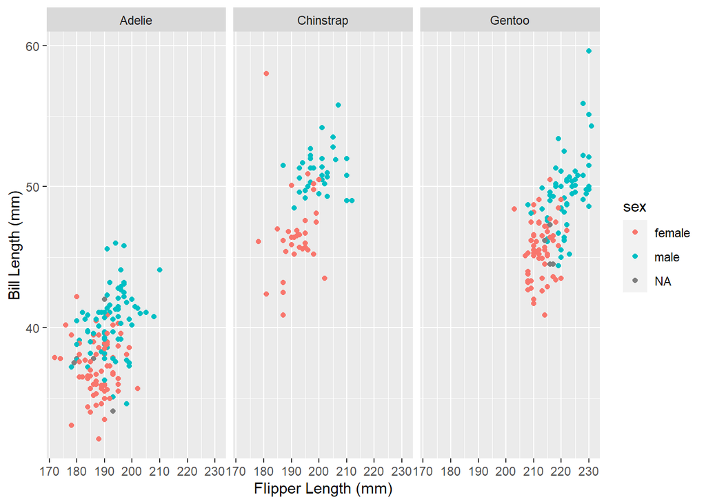

```r
penguins %>%
  ggplot(aes(x=flipper_length_mm, y=bill_length_mm, color=sex)) + geom_point() + xlab("Flipper Length (mm)") + ylab("Bill Length (mm)") + facet_wrap(~ species, ncol=3)
```

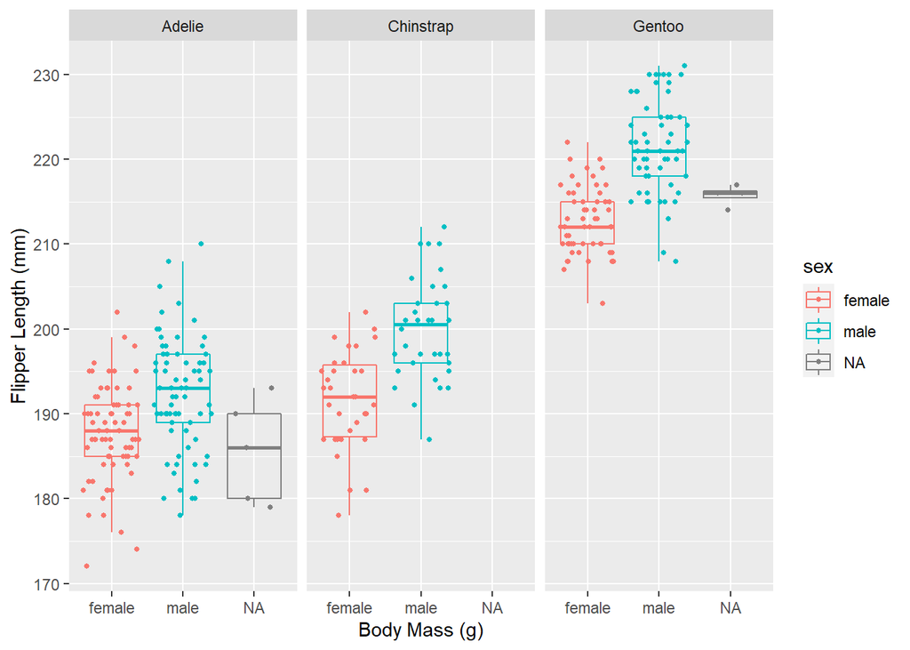

```r
penguins %>%
  ggplot(aes(x=flipper_length_mm, y=sex, color=sex)) + geom_boxplot(outlier.alpha = 0, alpha=0) + geom_jitter(width = 0, size=1) + xlab("Flipper Length (mm)") + ylab("Body Mass (g)") + facet_wrap(~species) + coord_flip()
```

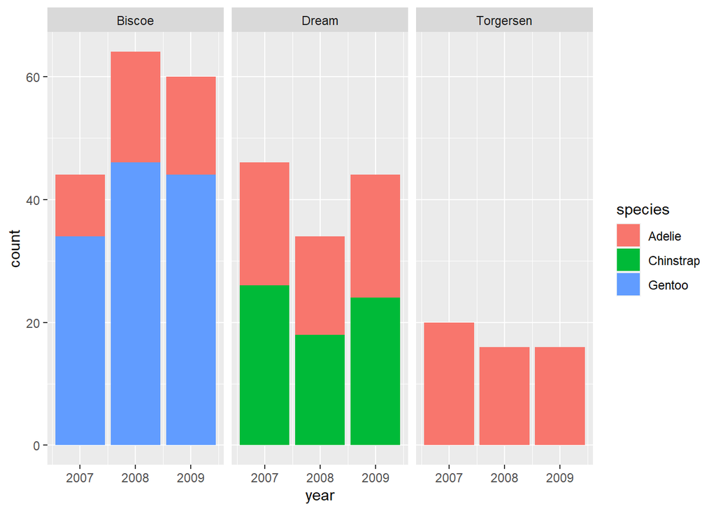

```r
penguins %>%
  ggplot() +
  geom_bar(mapping = aes(x=year, fill=species)) +
  facet_wrap(~island)
```